# Visualization using Seaborn

## Seaborn is a powerful data visualization library used for creating details visuals necessary to perform Python Analysis

### excel read package, to read excel files into jupyter notebook. After installing, always restart the kernel

```python
%pip install xlrd
```

```python
import pandas as pd
import seaborn as sns
import matplotlib.pyplot as plt
```

```python
path = r"E:\Sindhura\DataSets\Coffee Shop Sales.xlsx"
df = pd.read_excel(path)
df.head()
```

|  | transaction_id | transaction_date | transaction_time | transaction_qty | store_id | store_location | product_id | unit_price | product_category | product_type | product_detail |
| --- | --- | --- | --- | --- | --- | --- | --- | --- | --- | --- | --- |
| 0 | 1 | 2023-01-01 | 07:06:11 | 2 | 5 | Lower Manhattan | 32 | 3.0 | Coffee | Gourmet brewed coffee | Ethiopia Rg |
| 1 | 2 | 2023-01-01 | 07:08:56 | 2 | 5 | Lower Manhattan | 57 | 3.1 | Tea | Brewed Chai tea | Spicy Eye Opener Chai Lg |
| 2 | 3 | 2023-01-01 | 07:14:04 | 2 | 5 | Lower Manhattan | 59 | 4.5 | Drinking Chocolate | Hot chocolate | Dark chocolate Lg |
| 3 | 4 | 2023-01-01 | 07:20:24 | 1 | 5 | Lower Manhattan | 22 | 2.0 | Coffee | Drip coffee | Our Old Time Diner Blend Sm |
| 4 | 5 | 2023-01-01 | 07:22:41 | 2 | 5 | Lower Manhattan | 57 | 3.1 | Tea | Brewed Chai tea | Spicy Eye Opener Chai Lg |

```python
df.info()
```

```
<class 'pandas.core.frame.DataFrame'>
RangeIndex: 149116 entries, 0 to 149115
Data columns (total 11 columns):
 #   Column            Non-Null Count   Dtype
---  ------            --------------   -----
 0   transaction_id    149116 non-null  int64
 1   transaction_date  149116 non-null  datetime64[ns]
 2   transaction_time  149116 non-null  object
 3   transaction_qty   149116 non-null  int64
 4   store_id          149116 non-null  int64
 5   store_location    149116 non-null  object
 6   product_id        149116 non-null  int64
 7   unit_price        149116 non-null  float64
 8   product_category  149116 non-null  object
 9   product_type      149116 non-null  object
 10  product_detail    149116 non-null  object
dtypes: datetime64[ns](1), float64(1), int64(4), object(5)
memory usage: 12.5+ MB
```

**The default size of plots displayed in a Jupyter Notebook, when using Matplotlib, is typically 6.4 inches in width and 4.8 inches in height.**

## Countplot is used to show the count (frequency) of observations in each categorical bin.

#### Plot countplots that shows most popular product category

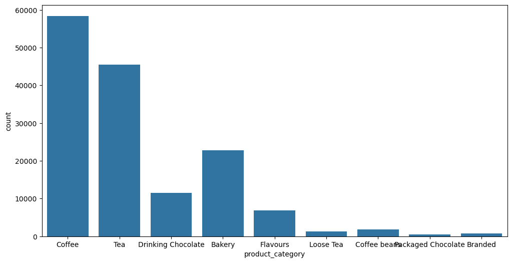

```python
plt.figure(figsize=(12,6))
sns.countplot(data=df,x='product_category')
plt.show()
```

## Bar plots is used when you want to show a numerical value (like average, sum, or median) for each category.

For bar plots, you need one numerical variable and one categorical variable

Black dot/line is referred as **error bars** in barsshows a 95% confidence interval for the mean. This means that the black line indicates the range within which the true mean is likely to lie with 95% confidence. These black lines are useful for statistical measures like mean/median. These are not useful for other estimators like sum,min,max. You can ignore those lines for such estimators.

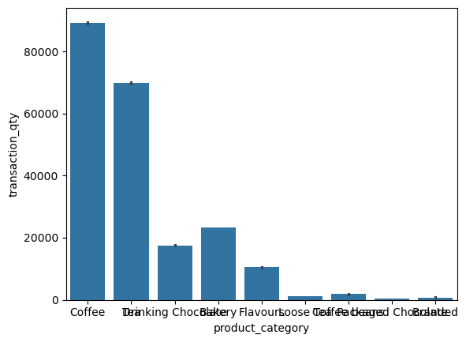

```python
sns.barplot(data=df,x='product_category',y='transaction_qty',estimator='sum') # estimator can be sum,mean,median,min,max
plt.show()
```

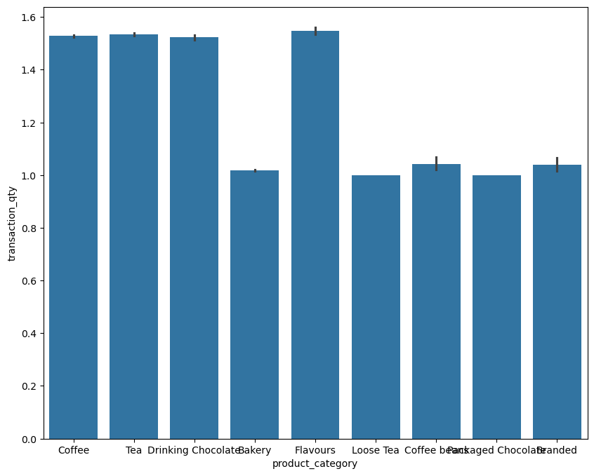

```python
plt.figure(figsize=(10,8))
sns.barplot(data=df,x='product_category',y='transaction_qty',estimator='mean') # estimator can be sum,mean,median,min,max
plt.show()
```

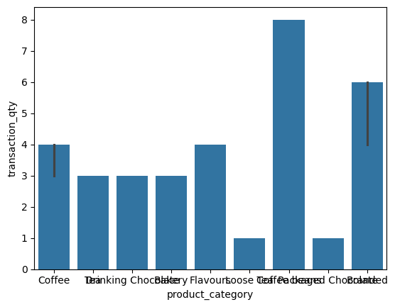

```python
sns.barplot(data=df,x='product_category',y='transaction_qty',estimator='max') # estimator can be sum,mean,median,min,max
plt.show()
```

#### Seaborns dont provide pie charts, however you can use matplolib for pichart plotting

## Histograms are used to understand the distribution of numerical variables

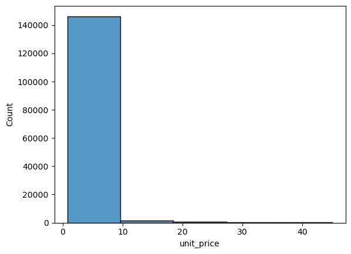

```python
sns.histplot(data=df,x='unit_price',bins=5)
plt.show()
```

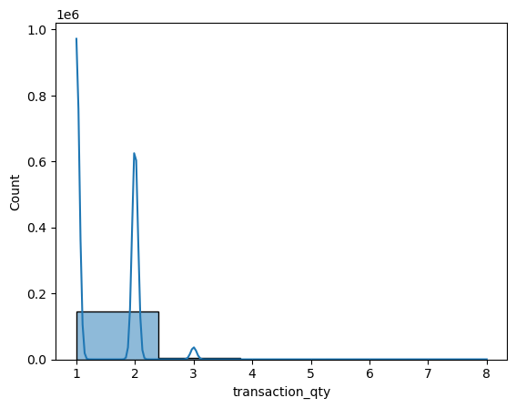

```python
sns.histplot(data=df,x='transaction_qty',bins=5,kde=True)
plt.show()
```

## Line chart is used to identify trends or patterns in data

#### Plot line chart that shows date wise quantities

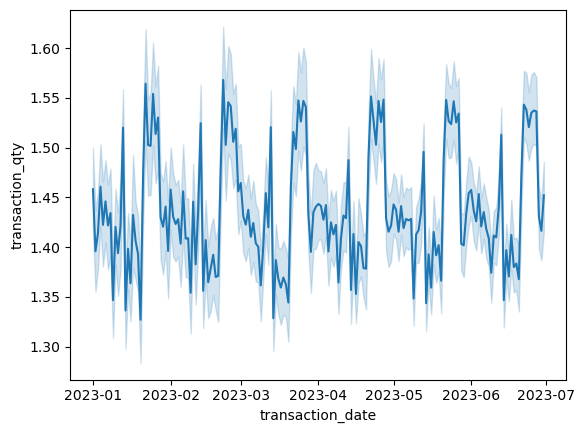

```python
sns.lineplot(data=df,x='transaction_date',y='transaction_qty')
plt.show()
```

```python
df['store_location'].unique()
```

```
array(['Lower Manhattan', "Hell's Kitchen", 'Astoria'], dtype=object)
```

## Plot line chart showing quantity wise transactions in Astoria Store

```python
A = df[df["store_location"] == 'Astoria']
A
```

|  | transaction_id | transaction_date | transaction_time | transaction_qty | store_id | store_location | product_id | unit_price | product_category | product_type | product_detail |
| --- | --- | --- | --- | --- | --- | --- | --- | --- | --- | --- | --- |
| 105 | 106 | 2023-01-01 | 11:01:48 | 1 | 3 | Astoria | 22 | 2.00 | Coffee | Drip coffee | Our Old Time Diner Blend Sm |
| 106 | 107 | 2023-01-01 | 11:01:58 | 1 | 3 | Astoria | 38 | 3.75 | Coffee | Barista Espresso | Latte |
| 107 | 108 | 2023-01-01 | 11:01:58 | 1 | 3 | Astoria | 75 | 3.50 | Bakery | Pastry | Croissant |
| 111 | 112 | 2023-01-01 | 11:08:11 | 1 | 3 | Astoria | 59 | 4.50 | Drinking Chocolate | Hot chocolate | Dark chocolate Lg |
| 113 | 114 | 2023-01-01 | 11:09:01 | 1 | 3 | Astoria | 59 | 4.50 | Drinking Chocolate | Hot chocolate | Dark chocolate Lg |
| ... | ... | ... | ... | ... | ... | ... | ... | ... | ... | ... | ... |
| 149103 | 149444 | 2023-06-30 | 19:51:59 | 2 | 3 | Astoria | 26 | 3.00 | Coffee | Organic brewed coffee | Brazilian Rg |
| 149104 | 149445 | 2023-06-30 | 19:52:28 | 2 | 3 | Astoria | 34 | 2.45 | Coffee | Premium brewed coffee | Jamaican Coffee River Sm |
| 149105 | 149446 | 2023-06-30 | 19:53:46 | 1 | 3 | Astoria | 24 | 3.00 | Coffee | Drip coffee | Our Old Time Diner Blend Lg |
| 149107 | 149448 | 2023-06-30 | 19:57:49 | 2 | 3 | Astoria | 54 | 2.50 | Tea | Brewed Chai tea | Morning Sunrise Chai Rg |
| 149108 | 149449 | 2023-06-30 | 19:57:49 | 1 | 3 | Astoria | 70 | 3.25 | Bakery | Scone | Cranberry Scone |

50599 rows × 11 columns

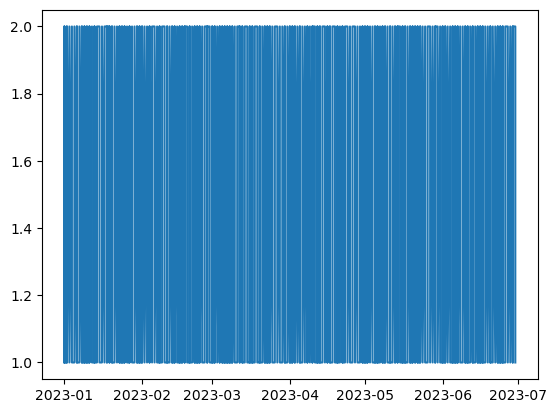

```python
plt.plot(A['transaction_date'],A['transaction_qty'])
plt.show()
```

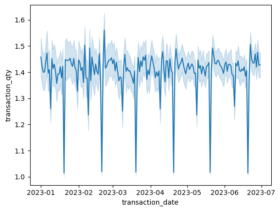

```python
sns.lineplot(data=A,x='transaction_date',y='transaction_qty')
plt.show()
```

#### Plot line chart that shows store wise quantity transactions

```python
df['store_location'].unique()
```

```
array(['Lower Manhattan', "Hell's Kitchen", 'Astoria'], dtype=object)
```

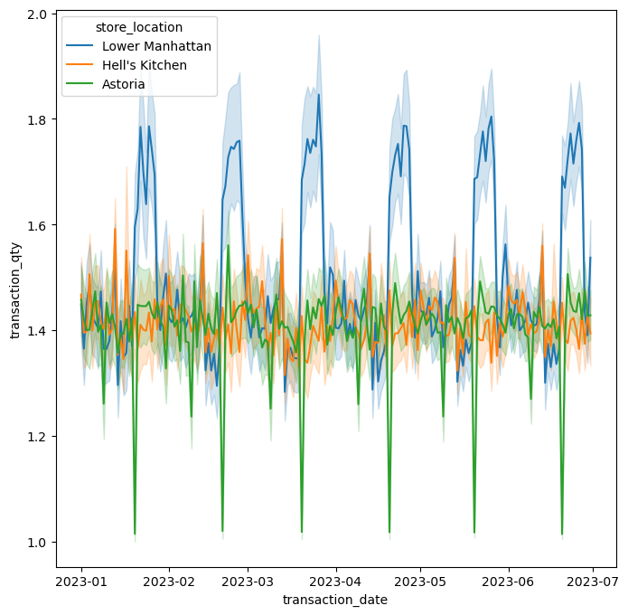

```python
plt.figure(figsize=(8,8))
sns.lineplot(data=df,x='transaction_date',y='transaction_qty',hue='store_location')
plt.show()
```

## Scatterplot shows the relationship between two numeric variables.

#### Plot scatterplot to identify relationship between unit price vs transaction quantity

```python
df.columns
```

```
Index(['transaction_id', 'transaction_date', 'transaction_time',
       'transaction_qty', 'store_id', 'store_location', 'product_id',
       'unit_price', 'product_category', 'product_type', 'product_detail'],
      dtype='object')
```

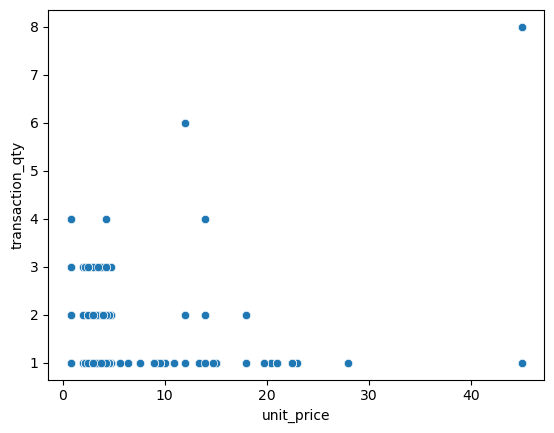

```python
sns.scatterplot(data=df,x='unit_price',y='transaction_qty')
plt.show()
```

## Scatterplots also help in grouping of data

for this you would use 2 numerical variables and one categorical variable(in hue)

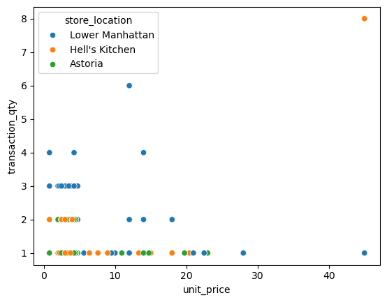

```python
sns.scatterplot(data=df,x='unit_price',y='transaction_qty',hue='store_location')
plt.show()
```

**Iris Dataset**

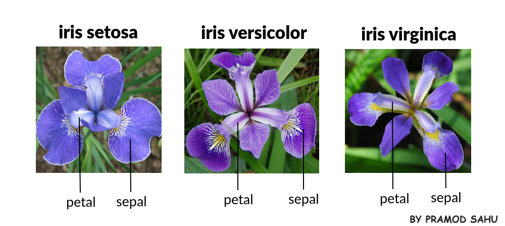

```python
path2 = r"E:\Sindhura\DataSets\iris.csv"
iris = pd.read_csv(path2)
iris.head()
```

|  | sepal_length | sepal_width | petal_length | petal_width | species |
| --- | --- | --- | --- | --- | --- |
| 0 | 5.1 | 3.5 | 1.4 | 0.2 | setosa |
| 1 | 4.9 | 3.0 | 1.4 | 0.2 | setosa |
| 2 | 4.7 | 3.2 | 1.3 | 0.2 | setosa |
| 3 | 4.6 | 3.1 | 1.5 | 0.2 | setosa |
| 4 | 5.0 | 3.6 | 1.4 | 0.2 | setosa |

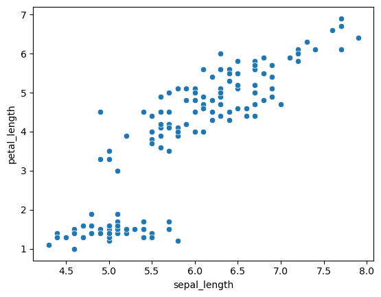

```python
sns.scatterplot(data=iris,x='sepal_length',y='petal_length')
plt.show()
```

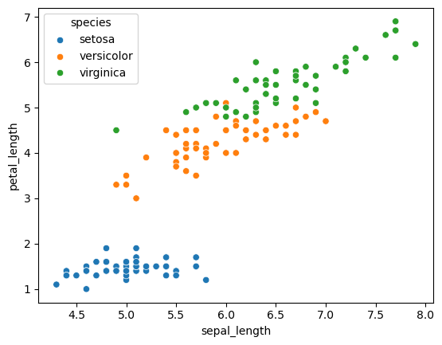

```python
sns.scatterplot(data=iris,x='sepal_length',y='petal_length',hue='species')
plt.show()
```

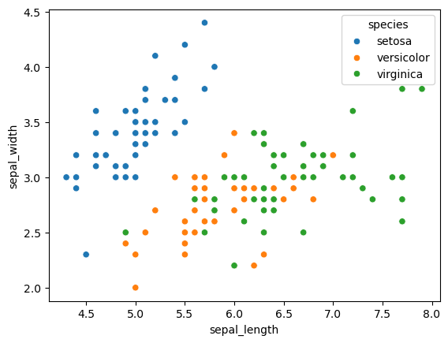

```python
sns.scatterplot(data=iris,x='sepal_length',y='sepal_width',hue='species')
plt.show()
```

## Box plots are used to identify outliers in the data

Box plots need one categorical variable and continuous variable

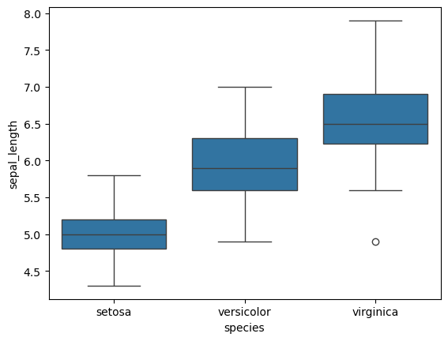

```python
sns.boxplot(data=iris,x='species',y='sepal_length')
```

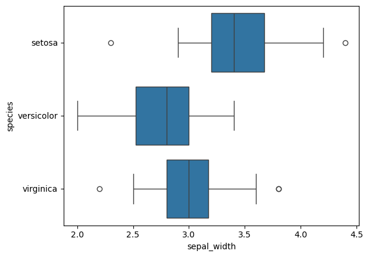

```python
sns.boxplot(data=iris,x='sepal_width',y='species')
```

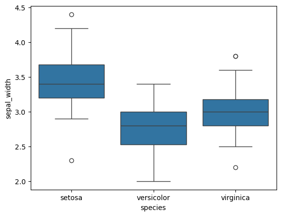

```python
sns.boxplot(data=iris,x='species',y='sepal_width')
```

**Tips dataset**

```python
path3 = r"E:\Sindhura\DataSets\tips.csv"
tips = pd.read_csv(path3)
tips.head()
```

|  | total_bill | tip | sex | smoker | day | time | size |
| --- | --- | --- | --- | --- | --- | --- | --- |
| 0 | 16.99 | 1.01 | Female | No | Sun | Dinner | 2 |
| 1 | 10.34 | 1.66 | Male | No | Sun | Dinner | 3 |
| 2 | 21.01 | 3.50 | Male | No | Sun | Dinner | 3 |
| 3 | 23.68 | 3.31 | Male | No | Sun | Dinner | 2 |
| 4 | 24.59 | 3.61 | Female | No | Sun | Dinner | 4 |

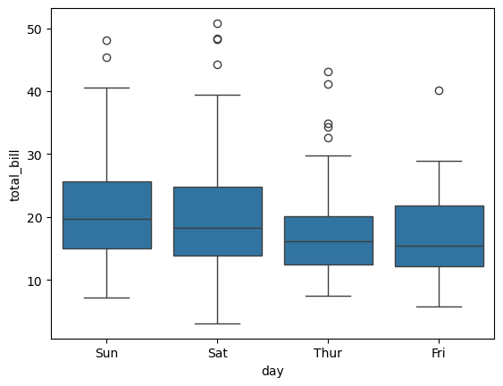

```python
sns.boxplot(data=tips,x='day',y='total_bill')
plt.show()
```

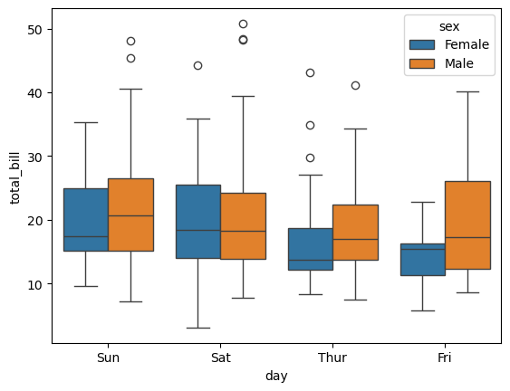

```python
sns.boxplot(data=tips,x='day',y='total_bill',hue='sex')
plt.show()
```

## Violin Plot are the combination of boxplot and kde curves

Useful to identify outliers and also understand the distribution of data

To read a violin plot, observe that its width represents the density of data at different values, with wider sections indicating higher frequency or probability of data points. The plot combines elements of a histogram and a box plot. The central box-plot-like element shows the median (a white dot) and the interquartile range (a thick gray bar). Examining the shape and comparing the violins helps understand data distribution and identify differences between groups.

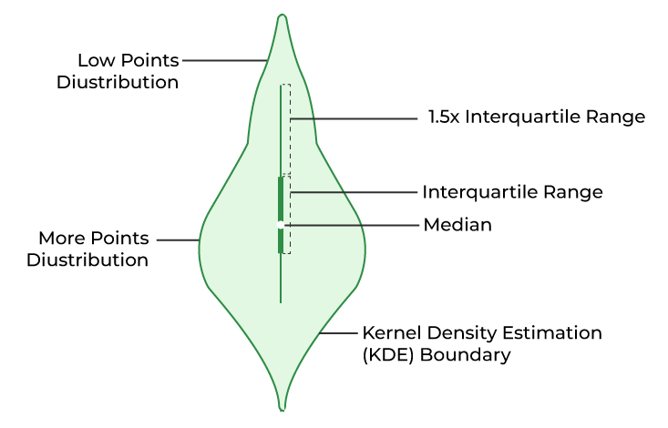

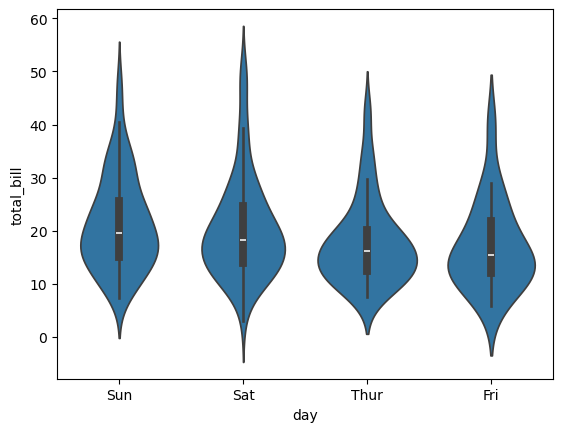

```python
sns.violinplot(data=tips,x='day',y='total_bill')
plt.show()
```

## Swarm Plot is used to show all data points for a categorical variable, while avoiding overlaps.

It’s like a scatter plot for categorical data, where points are adjusted so they don’t overlap.

Unlike boxplot or violin plot, which summarize distributions, a swarm plot shows every single data point.

Good for small/medium datasets where you want to see the raw data, not just summaries.

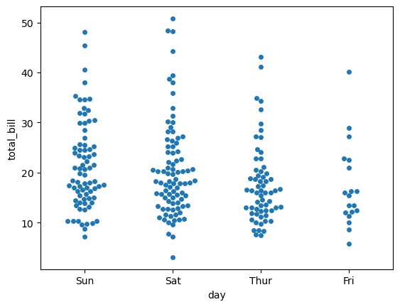

```python
sns.swarmplot(data=tips,x='day',y='total_bill')
plt.show()
```

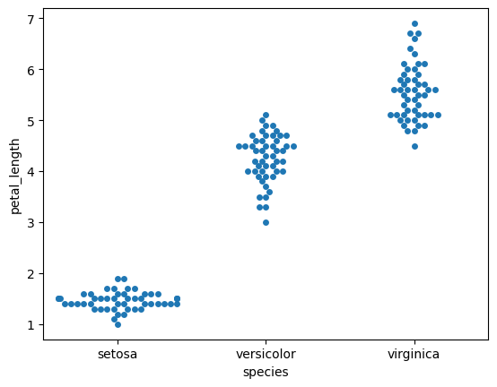

```python
sns.swarmplot(data=iris,x='species',y='petal_length')
plt.show()
```

## Heatmaps shows data values as a matrix (2D grid) where values are represented by color intensity.

Often used for:

Correlation matrices (to see relationships between variables).

Confusion matrices in ML.

Pivot tables (like Excel cross-tab).

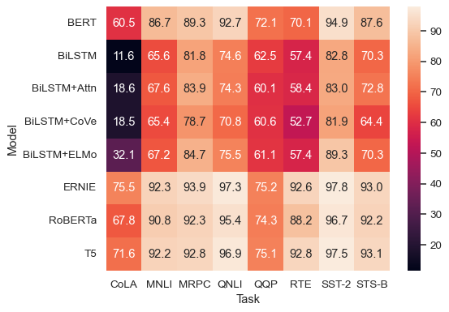

```python
import numpy as np
data = np.random.rand(10,10)
data
```

```
array([[0.16050916, 0.38866473, 0.68881916, 0.76668326, 0.20411202,
        0.51296225, 0.22999756, 0.20952723, 0.44447867, 0.34183255],
       [0.96744623, 0.10480114, 0.1755226 , 0.04496776, 0.39820655,
        0.02707716, 0.41056477, 0.18300987, 0.05788481, 0.06491833],
       [0.65023995, 0.791594  , 0.56319392, 0.53338021, 0.24546462,
        0.00457587, 0.77214549, 0.76314101, 0.26355704, 0.3252097 ],
       [0.51879634, 0.47014317, 0.52624951, 0.91481005, 0.74114429,
        0.74840492, 0.95506751, 0.60710391, 0.79641411, 0.80533271],
       [0.35967338, 0.15878389, 0.25620045, 0.51423644, 0.68307031,
        0.13063935, 0.5755398 , 0.01780299, 0.33931597, 0.82183728],
       [0.24483597, 0.55378533, 0.98537116, 0.35581104, 0.59828674,
        0.07314721, 0.97299611, 0.42576137, 0.55297857, 0.17943313],
       [0.84554213, 0.19317569, 0.06955214, 0.16401173, 0.9129061 ,
        0.1271405 , 0.03401714, 0.34057435, 0.56635146, 0.28957109],
       [0.93862848, 0.51985419, 0.72628368, 0.97496132, 0.50570148,
        0.77459084, 0.36098018, 0.93561502, 0.40891271, 0.22023295],
       [0.5058323 , 0.21117534, 0.1029179 , 0.68137049, 0.43411478,
        0.88629853, 0.23369509, 0.61040346, 0.95037773, 0.89773869],
       [0.27953174, 0.30405094, 0.61078771, 0.4598865 , 0.95253818,
        0.60798588, 0.08294913, 0.27726328, 0.03568351, 0.96583566]])
```

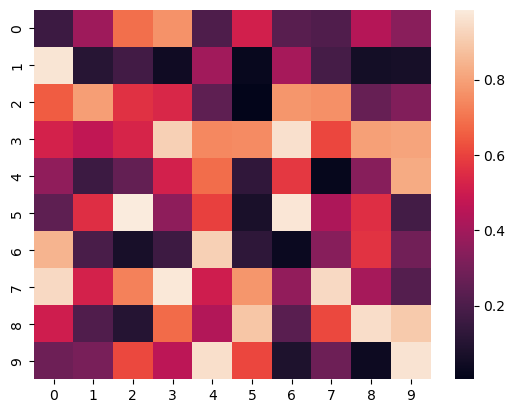

```python
sns.heatmap(data)
```

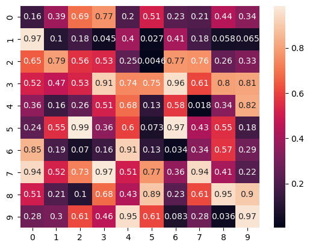

```python
sns.heatmap(data,annot=True)
```

### sns.heatmap(data,annot=True,fmt='d')

```python
con = list(df.columns[(df.dtypes == "int64") | (df.dtypes == "float64")])
con
```

```
['transaction_id', 'transaction_qty', 'store_id', 'product_id', 'unit_price']
```

```python
con.remove('transaction_id')
con.remove('store_id')
con.remove('product_id')
```

```python
con
```

```
['transaction_qty', 'unit_price']
```

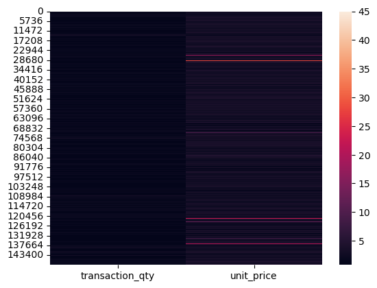

```python
sns.heatmap(df[con])
```

## Pairplots show cases multiple plots for numerical variables.

Histograms

Scatterplots

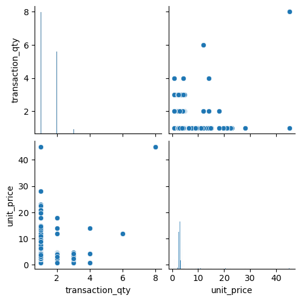

```python
sns.pairplot(df[con])
```

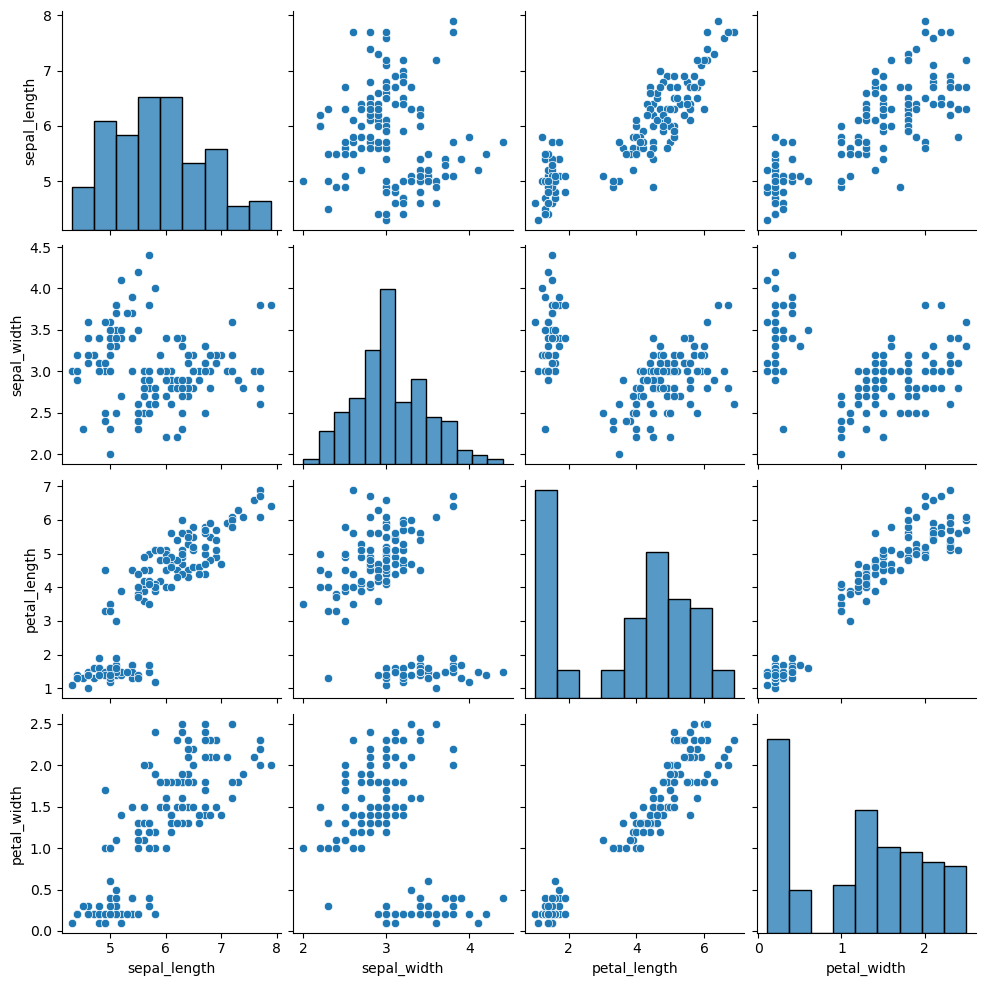

```python
con1 = list(iris.columns[iris.dtypes!="object"])
sns.pairplot(iris[con1])
```

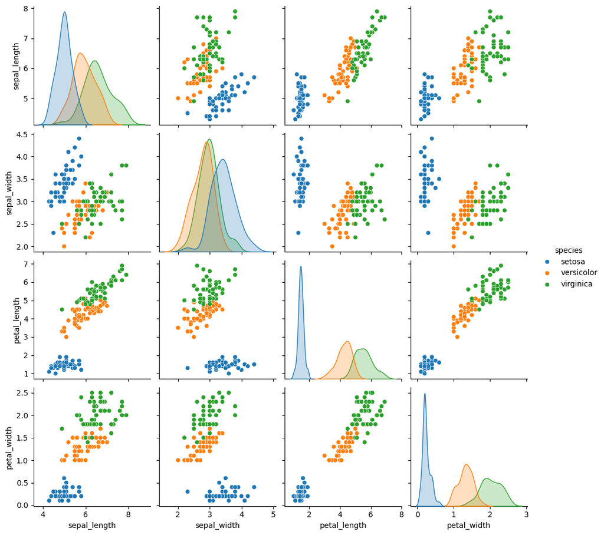

```python
sns.pairplot(iris,hue='species')
```

## FacetGrid helps you create multiple subplots (facets) for different subsets of your data.

```python
df.columns
```

```
Index(['transaction_id', 'transaction_date', 'transaction_time',
       'transaction_qty', 'store_id', 'store_location', 'product_id',
       'unit_price', 'product_category', 'product_type', 'product_detail'],
      dtype='object')
```

```python
df['store_location'].nunique()
```

```
3
```

```python
df['store_location'].unique()
```

```
array(['Lower Manhattan', "Hell's Kitchen", 'Astoria'], dtype=object)
```

```python
df['product_category'].nunique()
```

```
9
```

```python
df['product_category'].unique()
```

```
array(['Coffee', 'Tea', 'Drinking Chocolate', 'Bakery', 'Flavours',
       'Loose Tea', 'Coffee beans', 'Packaged Chocolate', 'Branded'],
      dtype=object)
```

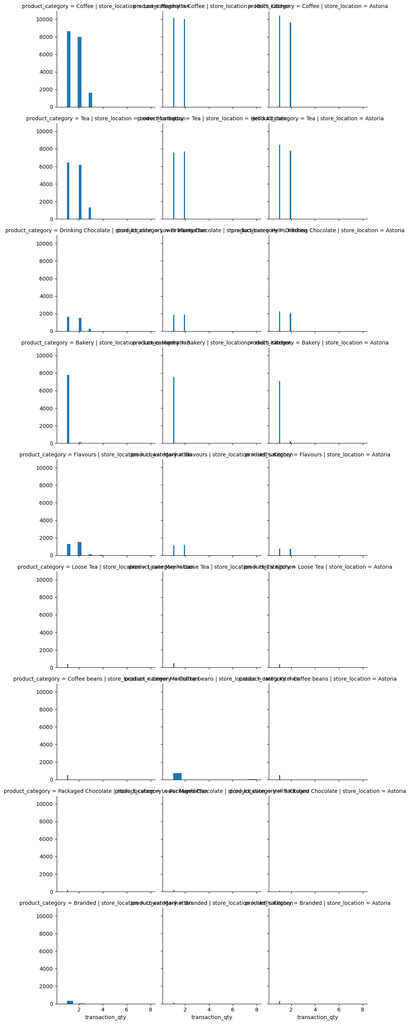

```python
g = sns.FacetGrid(data=df,col='store_location',row='product_category')
g.map(plt.hist,"transaction_qty")
```

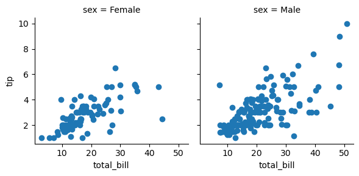

```python
g1 = sns.FacetGrid(data=tips,col='sex')
g1.map(plt.scatter,'total_bill','tip')
```

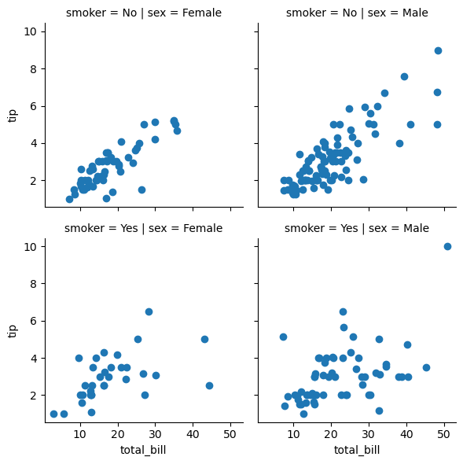

```python
g1 = sns.FacetGrid(data=tips,col='sex',row='smoker')
g1.map(plt.scatter,'total_bill','tip')
```

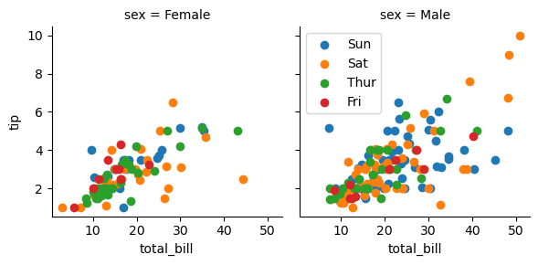

```python
g1 = sns.FacetGrid(data=tips,col='sex',hue='day')
g1.map(plt.scatter,'total_bill','tip')
plt.legend()
```

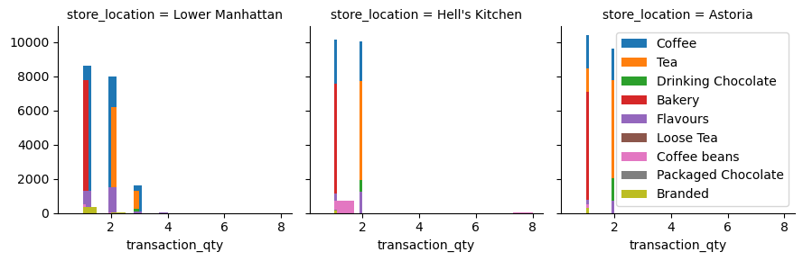

```python
g = sns.FacetGrid(data=df,col='store_location',hue='product_category')
g.map(plt.hist,"transaction_qty")
plt.legend()
plt.show()
```